# Predictive Modeling Process

## Introduction

- Credit.csv dataset

Table continues below

| Income | Limit | Rating | Cards | Age | Education | Gender |
| --- | --- | --- | --- | --- | --- | --- |
| 14.89 | 3606 | 283 | 2 | 34 | 11 | Male |
| 106 | 6645 | 483 | 3 | 82 | 15 | Female |

| Student | Married | Ethnicity | Balance |
| --- | --- | --- | --- |
| No | Yes | Caucasian | 333 |
| Yes | Yes | Asian | 903 |

- Want to predict `Balance` of an account, given ten predictors

## Methods

## Exploration of Variables

- Quantitative
  - Summary table of max, min, range, median, 1st and 3rd quartiles, IQR, mean, and sd
  - Histograms
  - Boxplots
- Qualitative
  - Frequency and Relative Frequency Tables
  - Barplots of Frequencies
  - Conditional Boxplots between Balance and the qualitative variable

## Example: Income

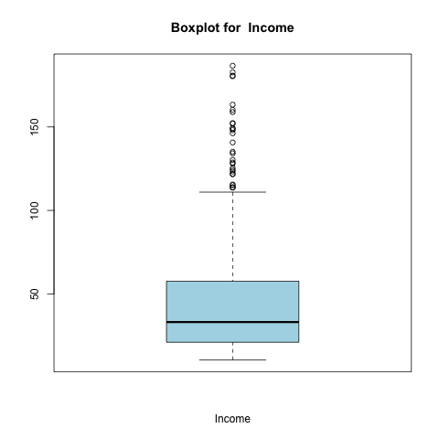

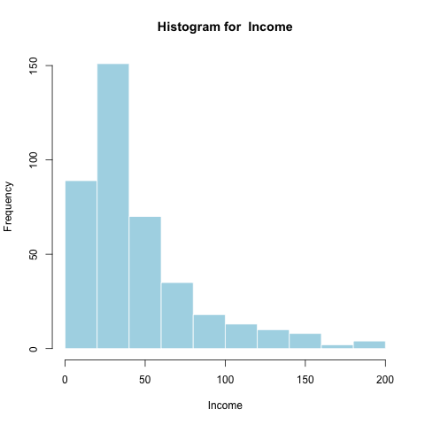

## Example: Student (yes or no)

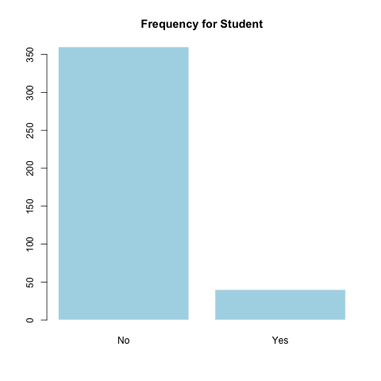

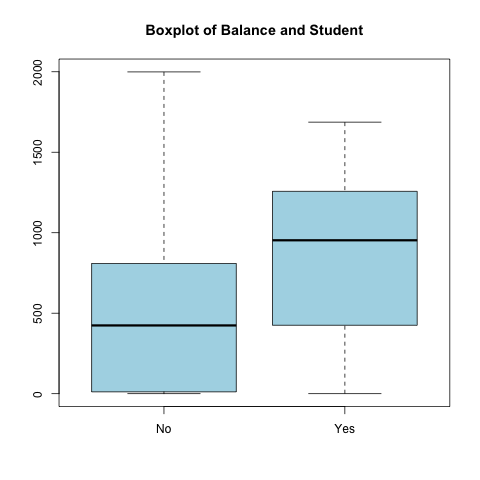

## Identifying Correlations

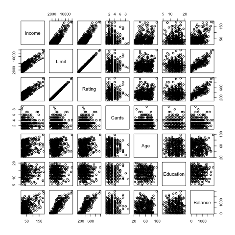

- `Income`, `Limit`, and `Rating` are correlated with `Balance`
- Highly correlated with each other

## Preparing the Data

- Dummy out the categorical variables

```
new_data <- model.matrix(Balance ~ ., data=data)
new_data <- cbind(new_data[ ,-1], Balance = data$Balance)
```

- Mean-center and standardize all variables

```
scaled_data <- scale(new_data, center = TRUE, scale = TRUE)
```

- Divide scaled data into training and test sets

## Regression Models

## Ordinary Least Squares

- Use `lm()` function
- Then find the coefficients and mse of the model

```
ols = lm(Balance~Income+Limit+Rating+Cards+Age+Education+GenderFemale
+StudentYes+MarriedYes+EthnicityAsian+EthnicityCaucasian, data=scaled_data)

ols_coeff = ols$coefficients[-1]

ols_mse = mean(ols$residuals^2)
```

## Ridge

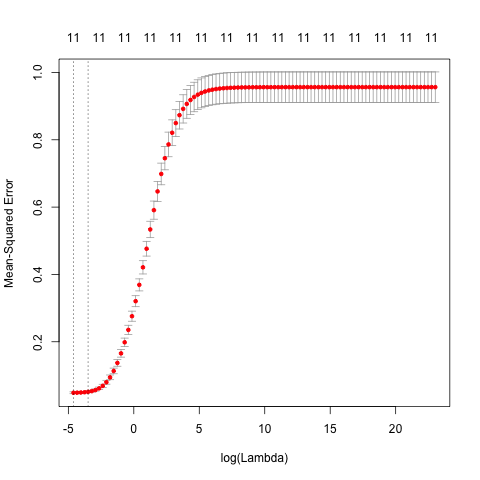

- Use `glmnet` R package
- First perform cross validation on the training set to find the value of lambda that results in the lowest cross validation error
- Smallest value of lambda is optimal

## Ridge: Continued

- Find mean squared error of the best model with this value of lambda on the test set

```
grid <- grid <- 10^(seq(10, -2, length = 100))
cv <- cv.glmnet(trainX, trainY, intercept = FALSE, standardize = FALSE,
lambda = grid, alpha=0)
lambda = cv$lambda.min

predictedY <- predict(cv, newx = testX, s = "lambda.min")
ssq <- sum((predictedY - testY)^2)
mse = ssq/nrow(testX)
```

- Using that value of lambda, refit the model on the whole dataset to find the official coefficients

```
fcv <- glmnet(dataX, dataY, intercept = FALSE, standardize = FALSE,
lambda = lambda,alpha=0)
```

## Lasso

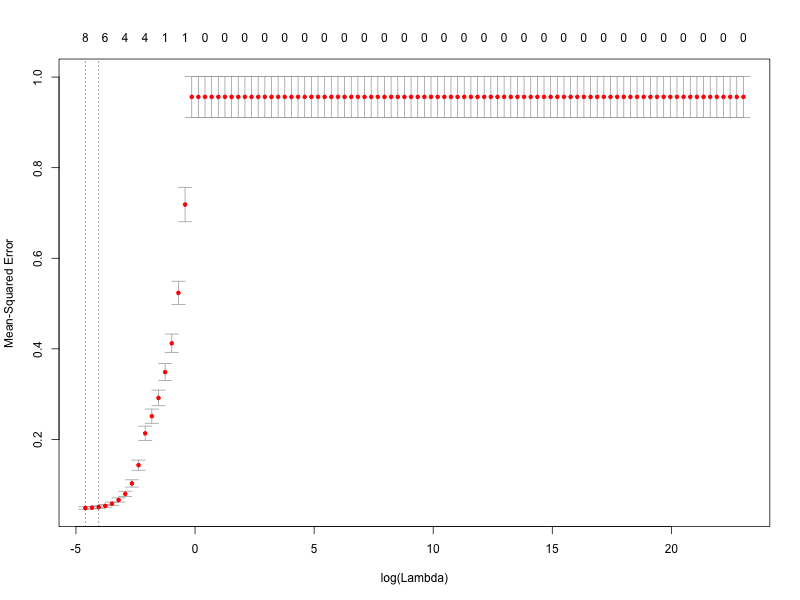

- Similar to Ridge, first perform cross validation to find best value of lambda
- Smallest value selected again

## Lasso Continued

```
cv_out = cv.glmnet(train_x, train_y, alpha=1, intercept=FALSE, standardize=FALSE,
lambda=grid)
lasso_lambda = cv_out$lambda.min
```

- Find the mse, then refit the model to find the official coefficients

```
lasso_pred = predict(lasso_mod, s = lasso_lambda, newx=test_x)
lasso_mse = mean((lasso_pred-test_y)^2)
lasso_out = glmnet(scaled_x, scaled_y, alpha=1, lambda=grid)
lasso_coeff = predict(lasso_out,type="coefficients",s=lasso_lambda)[2:12,]
```

## Principal Components

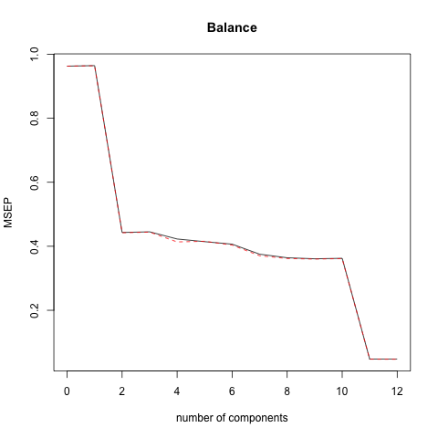

- Use `pls` R package
- Peform 10-fold cross-validation on training set to find optimal number of components (12)
- Fit model on full dataset to get final coefficients

```
pcr_model <- pcr(Balance ~ ., data=training, validation = "CV")
pcr_comp = which.min(pcr_model$validation$PRESS)
full_pcr_model <- pcr(Balance ~ ., data=data)
best_coefs <- full_pcr_model$coefficients[, , pcr_comp][-1]
```

## Partial Least Squares

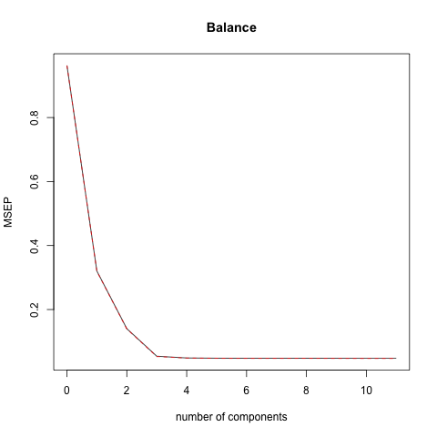

- Use `pls` package again
- Perform 10-fold cross validation to find the best number of components (6)
- Fit the model with this number of components to the whole dataset and find the coefficients

```
pls_fit = plsr(Balance ~ ., data=training_data,scale=TRUE, validation="CV")
pls_comp = which.min(pls_fit$validation$PRESS)
pls_pred = predict(pls_fit, test_x, ncomp=pls_comp)
pls_mse = mean((pls_pred-test_y)^2)
```

## Comparison of All Models

## Plot of Coefficients

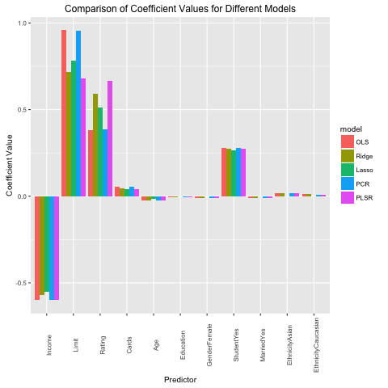

## Table of MSEs

MSE for Different Models

|  | OLS | Ridge | Lasso | PCR | PLSR |
| --- | --- | --- | --- | --- | --- |
| **MSE** | 0.04861 | 0.04832 | 0.04899 | 0.05051 | 0.04863 |

- We can see that all of the mses are fairly close together, with ridge producing the lowest mse by a small amount.